# Visualising the trajectory

```r
library(dyno)
library(tidyverse)
```

The main functions for plotting a trajectory are included in the dynplot package.

We’ll use an example toy dataset

```r
set.seed(1)
dataset <- dyntoy::generate_dataset(model = "bifurcating", num_cells = 200)
```

To visualise a trajectory, you have to take into acount two things:

- Where will I place the trajectory and cells in my 2D space
- What do I want to visualise along the trajectory based on color

Depending on the answer on these two questions, you will need different visualisations:

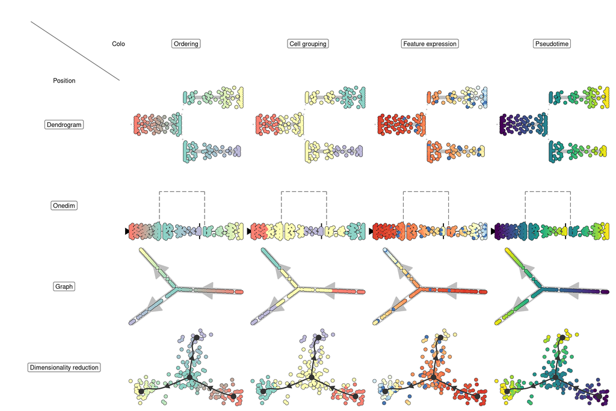

## Visualising the trajectory on a dimensionality reduction

The most common way to visualise a trajectory is to plot it on a dimensionality reduction of the cells. Often (but not always), a TI method will already output a dimensionality reduction itself, which was used to construct the trajectory. For example:

```r
model <- infer_trajectory(dataset, ti_mst())
head(get_dimred(model), 5)
```

```
##        comp_1      comp_2
## C1 -16.665552  -2.0932842
## C2  -6.100642  -5.8776537
## C3 -13.504351  -8.2116550
## C4 -15.828066   0.9743139
## C5   7.454530 -11.1981456
```

Dynplot will use this dimensionality reduction if available, otherwise it will calculate a dimensionality reduction under the hood:

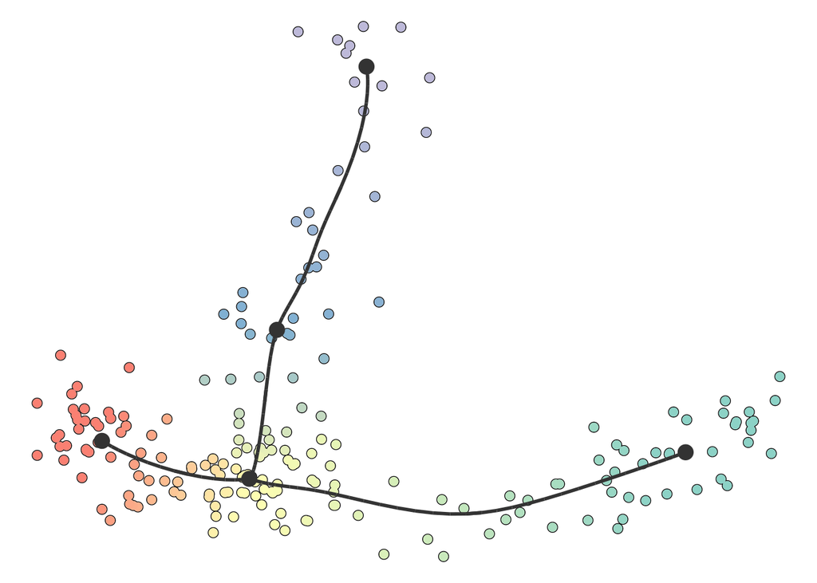

```r
plot_dimred(model)
## Coloring by milestone
## Using milestone_percentages from traj
```

You can also supply it with your own dimensionality reduction. In this case, the trajectory will be *projected* onto this dimensionality reduction.

```r
dimred <- dyndimred::dimred_umap(dataset$expression)
```

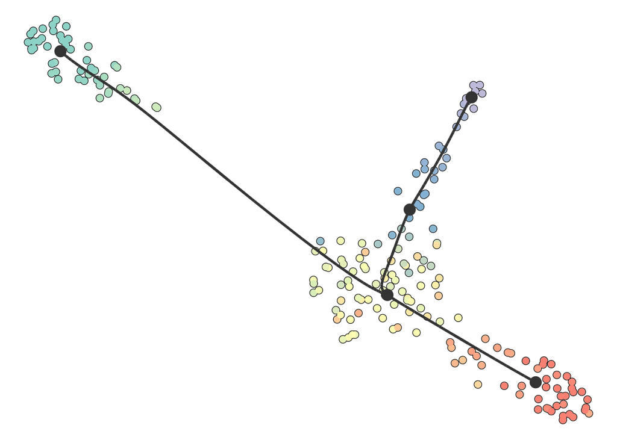

```r
plot_dimred(model, dimred = dimred)
## Coloring by milestone
## Using milestone_percentages from traj
```

On this plot, you can color the cells according to

1. **Cell ordering**. In which every milestone gets a color and the color changes gradually between the milestones. This is the default.
2. **Cell grouping**. A character vector mapping a cell to a group. In this example, we group the cells to their nearest milestone, but typically you will want to supply some external clustering here.
3. **Feature expression**. In which case you need to supply the `expression_source` which is usually the original dataset, but can be in any format accepted by `dynwrap::get_expression()`.
4. **Pseudotime**. The distance to a particular root milestone. The adapting tutorial discusses how to change the root of a trajectory.

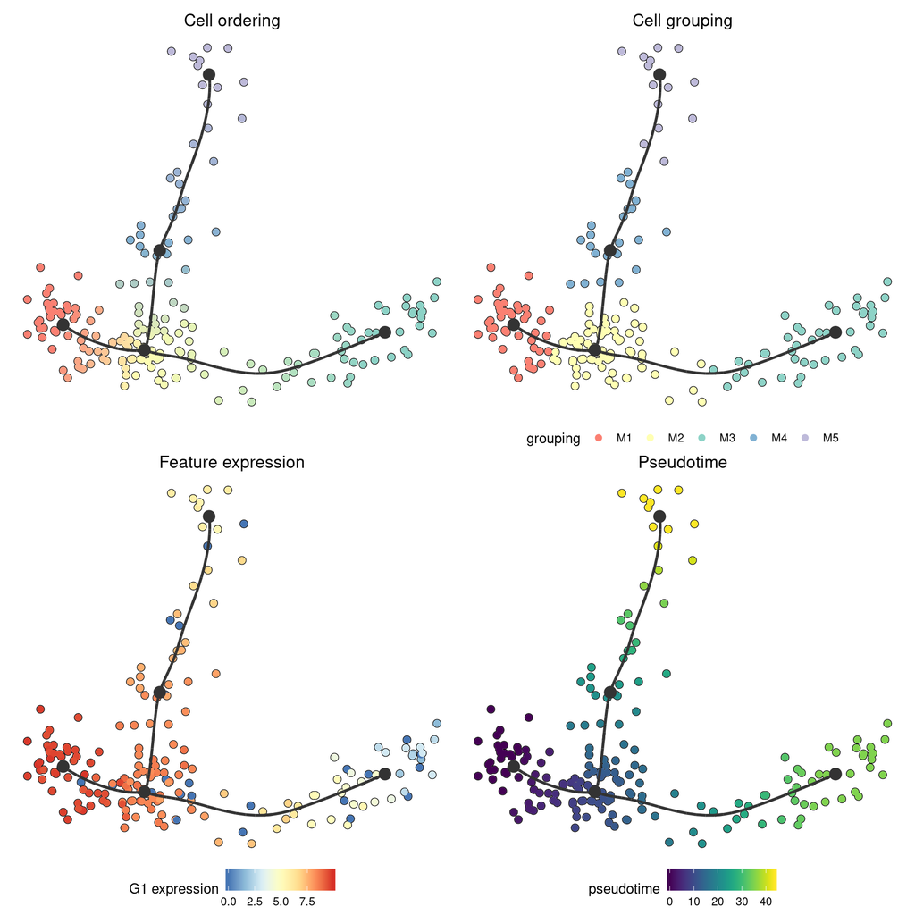

```r
patchwork::wrap_plots(
  plot_dimred(model) + ggtitle("Cell ordering"),
  plot_dimred(model, grouping = group_onto_nearest_milestones(model)) + ggtitle("Cell grouping"),
  plot_dimred(model, feature_oi = "G1", expression_source = dataset) + ggtitle("Feature expression"),
  plot_dimred(model, "pseudotime", pseudotime = calculate_pseudotime(model)) + ggtitle("Pseudotime")
)
## Coloring by milestone
## Using milestone_percentages from traj
## Coloring by grouping
## Coloring by expression
## root cell or milestone not provided, trying first outgoing milestone_id
## Using 'M1' as root
```

## Current limitations

Plotting of RNA velocity on top of a trajectory would be very *very* useful, but is not yet included. See the issue on github: https://github.com/dynverse/dynplot/issues/29